# Transport of glass eel

Cedric and Maria and Mathilde

07 november 2019

When trying to calibrate the model, sites where eels are translocated will act as outliers, diminishing the real effect of dams as eels are found above very large cumulated heights. For that reason the eels found above cumulated height of 150 m and 300 m have been analysed site by site. There can be several reasons why eels might be found there. The first is that operations of transport have taken place, those might of might not have been recorded. The second is that cumulated height are wrong. Reasons behing this are often duplicated dams, dams corresponding to penstock pipes with a lateral reservoir with the hpp located on the bank of the river but without impact on the river continuity. Dams recently built or simply planned and reported as being constructed. And finally, in France, where the dam database is very detailed, lateral dams often built in the downstream areas that are projected on the main river.

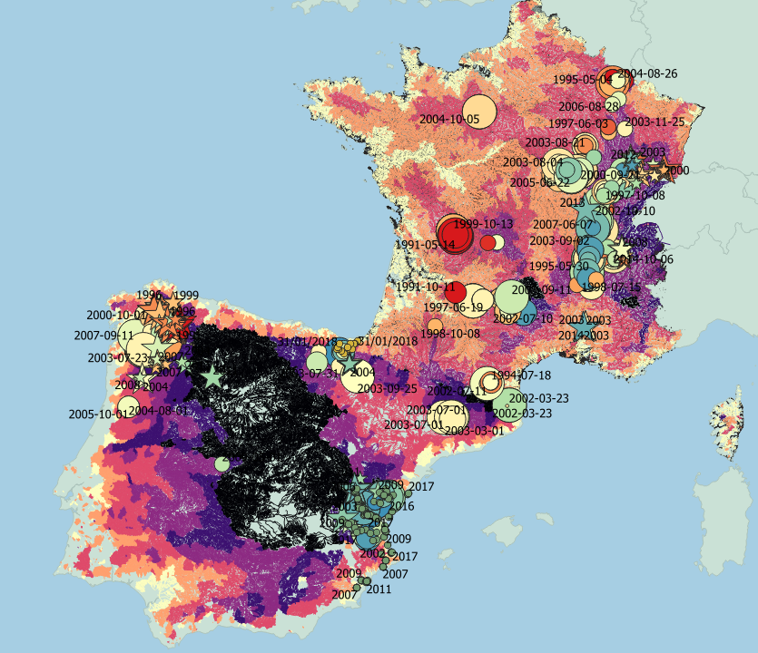

Possible transport sites in France, Spain and Portugal

## 0.1 Transport sites in France

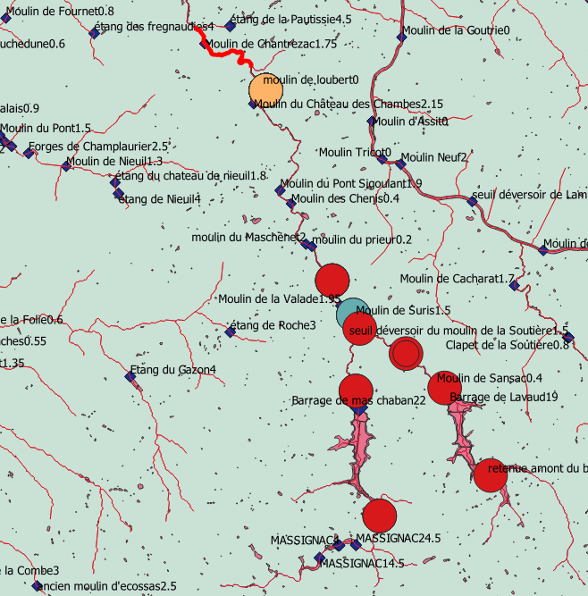

Transport Charente

Grouped points at the very top of the Charente Basin.

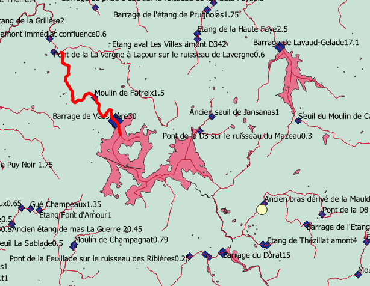

Transport Vienne arround Vassivière lake, transport corresponding probably to an angler association (AAPPMA)

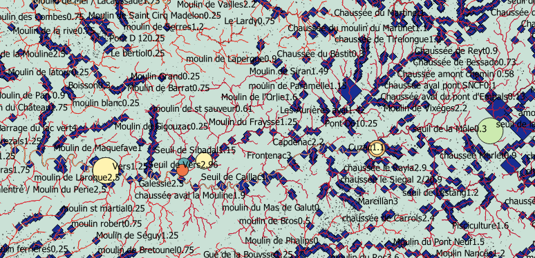

Several sites on the Lot basin

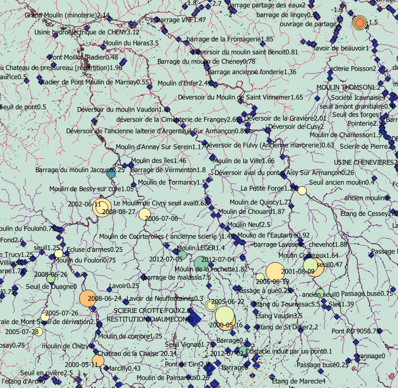

Many sites on the Yonne basin

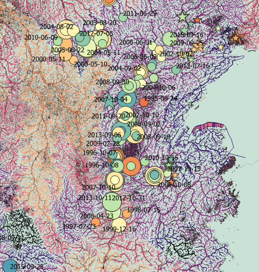

Many sites on the Rhône, there used to be transport by the commercial fishermen in the Saône

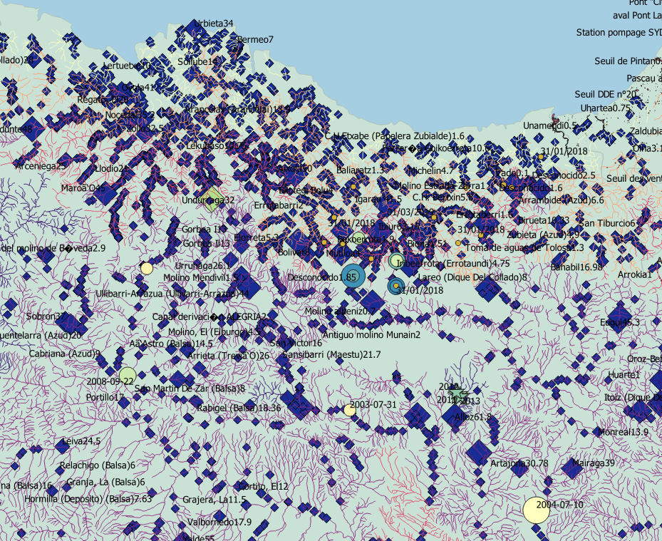

Transport sites in La Rioja & Navarra & Basque country

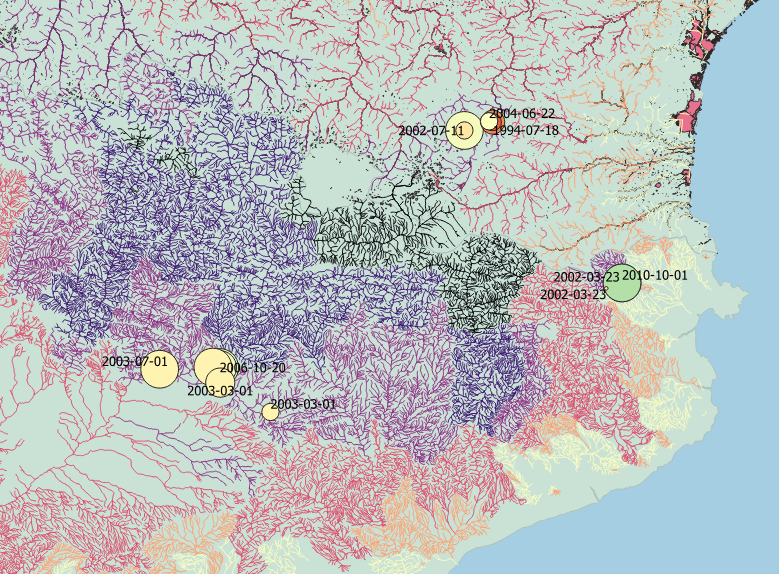

Transport sites in Cataluna, Aude amont

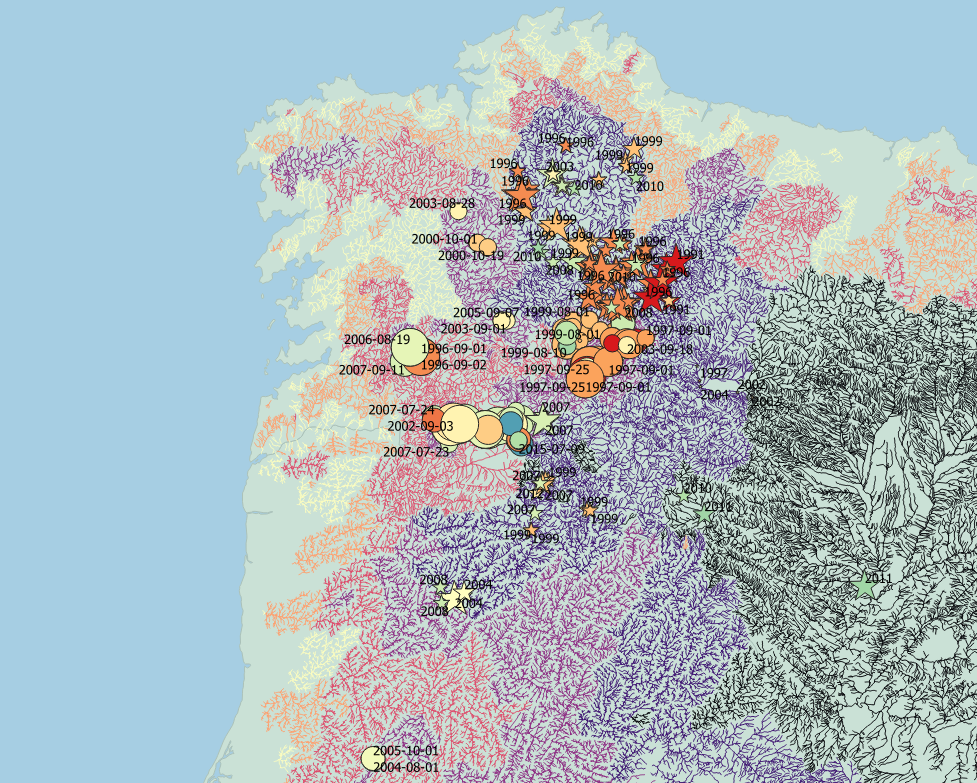

Transport sites for Mino, and surrounding area

## 0.2 Problems with projection in the downstream path of large rivers (France)

One of the reasons large cumulated height are sometimes found in France is that some obstacles are connected to lateral artificial canals or outlets that are not recorded in the RHT (the theoretical simplified river network used in France Pella et al. (2012)). Some of these dams have been attributed the category of dam (i.e. blocking more than the river bed) which is wrong, in fact those should be weirs. Since they are often a bit complex in their management, they don’t have a height, and the model of height used to predict uses the river flow in France. So these “lateral” obstacle are used in the model and some large rivers, free in their downstream course are attributed obstacles that don’t really exist. For that reason all dams predictions on rivers having a flow larger than 150 m3/s have been set a height of zero. They are selected by the following query.

```sql
/*
 this view allows to remove dams from the main streams when they are projected on the border
*/

DROP VIEW IF EXISTS sudoang.downstream_badly_projected;
create view sudoang.downstream_badly_projected as(
select  o.*,
rn_rna.seaidsegment,
  rn_rna.basin,
  rn_rna.riverwidthm,
  rn_rna.dis_m3_pyr_riveratlas from dbeel_rivers.join_obstruction_rn d
JOIn dbeel_rivers.rn_rna on rn_rna.idsegment=d.idsegment
JOIN sudoang.view_obstruction o on o.op_id=d.op_id
where dis_m3_pyr_riveratlas>150
and po_obstruction_height is NULL
and op_op_id is NULL
order by dis_m3_pyr_riveratlas);
```

[figure not shown]

Garonne a lateral canal

[figure not shown]

Garonne a lateral canal, with a predicted height of 24 m

[figure not shown]

Adour, outlets from lateral marshes, the Barthes, could lead to large predicted cumulated heights

## 0.3 final product

The final query to build the transported areas is as following : It creates a table with independent transport areas to fit in the model

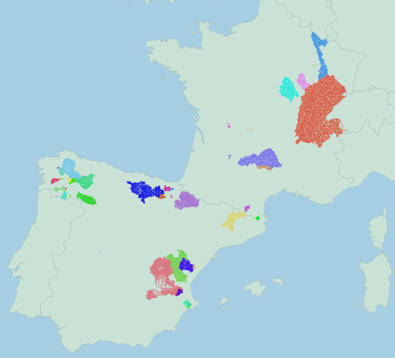

```sql
-- Charente : Barrages de Lavaud et Mas chaban (1984 2007 2013)
-- distance sea 367
-- transport_charente.png
-- cs_height10_p 166 m

CREATE TABLE dbeel_rivers.transport AS(

SELECT _idsegment AS idsegment, sector, "year" FROM  dbeel_rivers.upstream_segments_rn('FR100728')
CROSS JOIN (SELECT 'Charente' AS sector,1984 AS "year") sub

UNION

-- Vienne : barrage de Vassivière (2006)
--transport_vassiviere.png

SELECT _idsegment AS idsegment, sector, "year" FROM  dbeel_rivers.upstream_segments_rn('FR230915')
CROSS JOIN (SELECT 'Vassivière' AS sector, 2006 AS "year") sub1


UNION

SELECT 'FR231328' AS idsegment, 'Vienne' AS sector, 2006 AS "year"


UNION

-- le lot 66 m (cs_height) 123 m cs_height_p 315 km mer
--1995 => 2014
-- transport_lot.png

SELECT _idsegment AS idsegment, sector, "year"  FROM  dbeel_rivers.upstream_segments_rn('FR110889')
CROSS JOIN (SELECT 'Lot' AS sector, 1995 AS "year") sub3


-- La lède 1988 (affluent du lot)
UNION


SELECT _idsegment AS idsegment, sector, "year"  FROM  dbeel_rivers.upstream_segments_rn('FR110130')
CROSS JOIN (SELECT 'Lède' AS sector,  1988 AS "year") sub4

UNION
-- Le dropt  1988 (affluent du lot)

SELECT _idsegment AS idsegment, sector, "year"  FROM  dbeel_rivers.upstream_segments_rn('FR109171')
CROSS JOIN (SELECT 'Dropt' AS sector,  1988 AS "year") sub5

-- L'aude près PSICICULTURE FEDERALES  ...
-- transport_aude.png
UNION
SELECT _idsegment AS idsegment, sector, "year"  FROM  dbeel_rivers.upstream_segments_rn('FR24294')
CROSS JOIN (SELECT 'Aude' AS sector,  1994 AS "year") sub6


-- Aveyron (2 stations)
UNION
SELECT _idsegment AS idsegment, sector, "year"  FROM  dbeel_rivers.upstream_segments_rn('FR112201')
CROSS JOIN (SELECT 'Aveyron' AS sector,  2004 AS "year") sub7

-- yonne (43 m -- 151 m pred 634 km mer)
--1998
-- transport_yonne.png


UNION
SELECT _idsegment AS idsegment, sector, "year"  FROM  dbeel_rivers.upstream_segments_rn('FR317084')
CROSS JOIN (SELECT 'Yonne' AS sector,  1998 AS "year") sub8

--Marne

UNION
SELECT _idsegment AS idsegment, sector, "year"  FROM  dbeel_rivers.upstream_segments_rn('FR313384')
CROSS JOIN (SELECT 'Marne' AS sector,  1990 AS "year") sub9

--Seine Amont

UNION
SELECT _idsegment AS idsegment, sector, "year"  FROM  dbeel_rivers.upstream_segments_rn('FR316121')
CROSS JOIN (SELECT 'Seine' AS sector,  1990 AS "year") sub10




--Meuse

UNION
SELECT _idsegment AS idsegment, sector, "year"  FROM  dbeel_rivers.upstream_segments_rn('FR500284')
CROSS JOIN (SELECT 'Meuse' AS sector,  1985 AS "year") sub11


-- Rhone

UNION
SELECT _idsegment AS idsegment, sector, "year"  FROM  dbeel_rivers.upstream_segments_rn('FR9301')
CROSS JOIN (SELECT 'Rhone' AS sector,  1995 AS "year") sub12

-- Vale

UNION
SELECT _idsegment AS idsegment, sector, "year"  FROM  dbeel_rivers.upstream_segments_rn('SP61960')
CROSS JOIN (SELECT 'Rio Guadalest' AS sector,  1992 AS "year") sub13



UNION
SELECT _idsegment AS idsegment, sector, "year"  FROM  dbeel_rivers.upstream_segments_rn('SP63917')
CROSS JOIN (SELECT 'Rio Amadorio' AS sector,  2007 AS "year") sub14


UNION
SELECT _idsegment AS idsegment, sector, "year"  FROM  dbeel_rivers.upstream_segments_rn('SP58528')
CROSS JOIN (SELECT 'Rio Serpis' AS sector,  2007 AS "year") sub15


UNION
SELECT _idsegment AS idsegment, sector, "year"  FROM  dbeel_rivers.upstream_segments_rn('SP43630')
CROSS JOIN (SELECT 'Rio Jucar' AS sector,  2001 AS "year") sub16

UNION
SELECT _idsegment AS idsegment, sector, "year"  FROM  dbeel_rivers.upstream_segments_rn('SP50192')
CROSS JOIN (SELECT 'Rio Cazunta' AS sector,  2015 AS "year") sub17

UNION
SELECT _idsegment AS idsegment, sector, "year"  FROM  dbeel_rivers.upstream_segments_rn('SP44871')
CROSS JOIN (SELECT 'Rio Turia o Guadalaviar' AS sector,  1995 AS "year") sub18

UNION
SELECT _idsegment AS idsegment, sector, "year"  FROM  dbeel_rivers.upstream_segments_rn('SP44871')
CROSS JOIN (SELECT 'Rio Turia o Guadalaviar' AS sector,  1995 AS "year") sub19


UNION
SELECT _idsegment AS idsegment, sector, "year"  FROM  dbeel_rivers.upstream_segments_rn('SP44871')
CROSS JOIN (SELECT 'Riu Palancia' AS sector,  2015 AS "year") sub20


UNION
SELECT _idsegment AS idsegment, sector, "year"  FROM  dbeel_rivers.upstream_segments_rn('SP33591')
CROSS JOIN (SELECT 'Riu Mijares' AS sector,  2008 AS "year") sub21

UNION
SELECT _idsegment AS idsegment, sector, "year"  FROM  dbeel_rivers.upstream_segments_rn('SP30468')
CROSS JOIN (SELECT 'Riu Lucena' AS sector,  2009 AS "year") sub22

-- there are NOT reported

UNION
SELECT _idsegment AS idsegment, sector, "year"  FROM  dbeel_rivers.upstream_segments_rn('SP286559')
CROSS JOIN (SELECT 'Riu Segre' AS sector,  2002 AS "year") sub23

UNION
SELECT _idsegment AS idsegment, sector, "year"  FROM  dbeel_rivers.upstream_segments_rn('SP120302')
CROSS JOIN (SELECT 'Riu Muga' AS sector,  2002 AS "year") sub24

UNION
SELECT _idsegment AS idsegment, sector, "year"  FROM  dbeel_rivers.upstream_segments_rn('SP264971')
CROSS JOIN (SELECT 'Rio Aragon' AS sector,  2002 AS "year") sub25

UNION
SELECT _idsegment AS idsegment, sector, "year"  FROM  dbeel_rivers.upstream_segments_rn('SP238906')
CROSS JOIN (SELECT 'Rio Ubagua' AS sector,  2009 AS "year") sub26

UNION
SELECT _idsegment AS idsegment, sector, "year"  FROM  dbeel_rivers.upstream_segments_rn('SP241801')
CROSS JOIN (SELECT 'Rio Ega' AS sector,  2003 AS "year") sub27

UNION
SELECT _idsegment AS idsegment, sector, "year"  FROM  dbeel_rivers.upstream_segments_rn('SP240328')
CROSS JOIN (SELECT 'Rio Ebro' AS sector,  2008 AS "year") sub28

UNION
SELECT _idsegment AS idsegment, sector, "year"  FROM  dbeel_rivers.upstream_segments_rn('SP232597')
CROSS JOIN (SELECT 'Araxes Ibaia' AS sector,  2018 AS "year") sub29

UNION
SELECT _idsegment AS idsegment, sector, "year"  FROM  dbeel_rivers.upstream_segments_rn('SP231807')
CROSS JOIN (SELECT 'Leitzaran Ibaia' AS sector,  2018 AS "year") sub30



-- 2015 and 2018
UNION
SELECT _idsegment AS idsegment, sector, "year"  FROM  dbeel_rivers.upstream_segments_rn('SP231292')
CROSS JOIN (SELECT 'Oria Ibaia' AS sector,  2015 AS "year") sub33

UNION
SELECT _idsegment AS idsegment, sector, "year"  FROM  dbeel_rivers.upstream_segments_rn('SP233795')
CROSS JOIN (SELECT 'Rio Agauntza' AS sector,  2007 AS "year") sub34

UNION
SELECT _idsegment AS idsegment, sector, "year"  FROM  dbeel_rivers.upstream_segments_rn('SP233817')
CROSS JOIN (SELECT 'Txiki Erreka' AS sector, 2018  AS "year") sub35


UNION
SELECT _idsegment AS idsegment, sector, "year"  FROM  dbeel_rivers.upstream_segments_rn('SP230385')
CROSS JOIN (SELECT 'Urola Ibaia' AS sector,  2018 AS "year") sub36

UNION
SELECT _idsegment AS idsegment, sector, "year"  FROM  dbeel_rivers.upstream_segments_rn('SP232288')
CROSS JOIN (SELECT 'Antzinako Erreka' AS sector,  2018 AS "year") sub37

UNION
SELECT _idsegment AS idsegment, sector, "year"  FROM  dbeel_rivers.upstream_segments_rn('SP233592')
CROSS JOIN (SELECT 'Olaran Erreka' AS sector,  2018 AS "year") sub38

UNION
SELECT _idsegment AS idsegment, sector, "year"  FROM  dbeel_rivers.upstream_segments_rn('SP255753')
CROSS JOIN (SELECT 'Rio Navia' AS sector,  1990 AS "year") sub39

UNION
SELECT _idsegment AS idsegment, sector, "year"  FROM  dbeel_rivers.upstream_segments_rn('SP163646')
CROSS JOIN (SELECT 'Rio Minno' AS sector,  1999 AS "year") sub40

UNION



-- A single point but possible error so far upstream on the Tejo
UNION
SELECT 'SP206198' AS idsegment, 'RIO DE RAMACASTAÑAS O PRADO LATORRE' AS sector, 2009 AS "year"
) --51143 2h22






DELETE FROM dbeel_rivers.transport WHERE sector='Rio Tera'; --2020


INSERT INTO dbeel_rivers.transport
SELECT _idsegment AS idsegment, sector, "year"  FROM  dbeel_rivers.upstream_segments_rn('SP294614')
CROSS JOIN (SELECT 'Rio Tera' AS sector,  2011 AS "year") sub

-- no double ok:
DELETE FROM dbeel_rivers.transport WHERE idsegment IN (
SELECT idsegment
FROM
  (SELECT idsegment,
          rank() OVER (PARTITION BY idsegment) AS pos
     FROM dbeel_rivers.transport
  ) AS ss
WHERE pos >1;




ALTER TABLE  dbeel_rivers.transport  DROP COLUMN geom;
SELECT AddGeometryColumn ('dbeel_rivers','transport','geom',3035,'MULTILINESTRING',2, false);
UPDATE dbeel_rivers.transport set geom=rn.geom FROM
                dbeel_rivers.rn  WHERE rn.idsegment=transport.idsegment;--50662

INSERT INTO dbeel_rivers.transport(idsegment,sector,"year",geom)
SELECT idsegment, sector, "year", geom
FROM
spain.rn
CROSS JOIN (SELECT 'Rio Tamega' AS sector,  1999 AS "year") sub
WHERE idsegment IN (SELECT
dbeel_rivers.upstream_segments_rn('SP296436'));


INSERT INTO dbeel_rivers.transport(idsegment,sector,"year",geom)
SELECT idsegment, sector, "year", geom
FROM
spain.rn
CROSS JOIN (SELECT 'Rio da riberina de San Lourenzo' AS sector,  1999 AS "year") sub
WHERE idsegment IN (SELECT
dbeel_rivers.upstream_segments_rn('SP290384')); --472



INSERT INTO dbeel_rivers.transport(idsegment,sector,"year",geom)
SELECT idsegment, sector, "year", geom
FROM
spain.rn
CROSS JOIN (SELECT 'Rios Lor' AS sector,  1989 AS "year") sub
WHERE idsegment IN (SELECT
dbeel_rivers.upstream_segments_rn('SP167721')); --472


INSERT INTO dbeel_rivers.transport(idsegment,sector,"year",geom)
SELECT idsegment, sector, "year", geom
FROM
spain.rn
CROSS JOIN (SELECT 'Rio mao' AS sector,  1989 AS "year") sub
WHERE idsegment IN (SELECT
dbeel_rivers.upstream_segments_rn('SP169708')); --31


INSERT INTO dbeel_rivers.transport(idsegment,sector,"year",geom)
SELECT idsegment, sector, "year", geom
FROM
spain.rn
CROSS JOIN (SELECT 'Rio arnoia' AS sector,  1995 AS "year") sub
WHERE idsegment IN (SELECT
dbeel_rivers.upstream_segments_rn('SP170986')); --445


INSERT INTO dbeel_rivers.transport(idsegment,sector,"year",geom)
SELECT idsegment, sector, "year", geom
FROM
spain.rn
CROSS JOIN (SELECT 'Rio Avia' AS sector,  2006 AS "year") sub
WHERE idsegment IN (SELECT
dbeel_rivers.upstream_segments_rn('SP168413'));--393


INSERT INTO dbeel_rivers.transport(idsegment,sector,"year",geom)
SELECT idsegment, sector, "year", geom
FROM
spain.rn
CROSS JOIN (SELECT 'Rio Cabe' AS sector,  1999 AS "year") sub
WHERE idsegment IN (SELECT
dbeel_rivers.upstream_segments_rn('SP166299'));--327

INSERT INTO dbeel_rivers.transport(idsegment,sector,"year",geom)
SELECT idsegment, sector, "year", geom
FROM
spain.rn
CROSS JOIN (SELECT 'Rio Amsa' AS sector,  2003 AS "year") sub
WHERE idsegment IN (SELECT
dbeel_rivers.upstream_segments_rn('SP1208'));--27


INSERT INTO dbeel_rivers.transport(idsegment,sector,"year",geom)
SELECT idsegment, sector, "year", geom
FROM
spain.rn
CROSS JOIN (SELECT 'Rio Iso' AS sector,  2003 AS "year") sub
WHERE idsegment IN (SELECT
dbeel_rivers.upstream_segments_rn('SP186399'));--27

INSERT INTO dbeel_rivers.transport(idsegment,sector,"year",geom)
SELECT idsegment, sector, "year", geom
FROM
spain.rn
CROSS JOIN (SELECT 'Rio Ulla' AS sector,  2000 AS "year") sub
WHERE idsegment IN (SELECT
dbeel_rivers.upstream_segments_rn('SP183112'));--303


INSERT INTO dbeel_rivers.transport(idsegment,sector,"year",geom)
SELECT idsegment, sector, "year", geom
FROM
spain.rn
CROSS JOIN (SELECT 'Rio Sil' AS sector,  1997 AS "year") sub
WHERE idsegment IN (SELECT
dbeel_rivers.upstream_segments_rn('SP167099'));--1978
```